# Reproducible Data Project 2

chrisgoose

8/14/2019

# The Effects of Storm & Severe Weather on Economics & Population Health

## Intro

Storms and other severe weather events can cause both public health and economic problems for communities and municipalities. Many severe events can result in fatalities, injuries, and property damage, and preventing such outcomes to the extent possible is a key concern.

This project involves exploring the U.S. National Oceanic and Atmospheric Administration’s (NOAA) storm database. This database tracks characteristics of major storms and weather events in the United States, including when and where they occur, as well as estimates of any fatalities, injuries, and property damage.

The basic goal of this assignment is to explore the NOAA Storm Database and answer some basic questions about severe weather events.

My data analysis addresses the following questions:

1. Across the United States, which types of events are most harmful with respect to population health?
2. Across the United States, which types of events have the greatest economic consequences?

This report could be read by a government or municipal manager who might be responsible for preparing for severe weather events and will need to prioritize resources for different types of events. However, there are no specific recommendations in my report.

## Data Processing

First, I downloaded the NOAA storm database and extracted the file. I removed most of the variables to create a lower dimension dataset. I kept variables related to event type, number of fatalities, number of injuries, value of property damage, and value of crop damage.

```r
##Here are the data for the project:
url <- "https://d396qusza40orc.cloudfront.net/repdata%2Fdata%2FStormData.csv.bz2"

if(!file.exists("repdata_data_StormData.csv.bz2")) {
        download.file(url, "repdata_data_StormData.csv.bz2", method="curl")
}
stormData <- read.csv("repdata_data_StormData.csv.bz2")

colnames(stormData)
```

```
##  [1] "STATE__"    "BGN_DATE"   "BGN_TIME"   "TIME_ZONE"  "COUNTY"
##  [6] "COUNTYNAME" "STATE"      "EVTYPE"     "BGN_RANGE"  "BGN_AZI"
## [11] "BGN_LOCATI" "END_DATE"   "END_TIME"   "COUNTY_END" "COUNTYENDN"
## [16] "END_RANGE"  "END_AZI"    "END_LOCATI" "LENGTH"     "WIDTH"
## [21] "F"          "MAG"        "FATALITIES" "INJURIES"   "PROPDMG"
## [26] "PROPDMGEXP" "CROPDMG"    "CROPDMGEXP" "WFO"        "STATEOFFIC"
## [31] "ZONENAMES"  "LATITUDE"   "LONGITUDE"  "LATITUDE_E" "LONGITUDE_"
## [36] "REMARKS"    "REFNUM"
```

```r
#create lower dimension table
stormData2 <- stormData[, c("REFNUM", "EVTYPE", "FATALITIES", "INJURIES",
                            "PROPDMG", "PROPDMGEXP", "CROPDMG", "CROPDMGEXP")]

str (stormData2)
```

```
## 'data.frame':    902297 obs. of  8 variables:
##  $ REFNUM    : num  1 2 3 4 5 6 7 8 9 10 ...
##  $ EVTYPE    : Factor w/ 985 levels "   HIGH SURF ADVISORY",..: 834 834 834 834 834 834 834 834 834 834 ...
##  $ FATALITIES: num  0 0 0 0 0 0 0 0 1 0 ...
##  $ INJURIES  : num  15 0 2 2 2 6 1 0 14 0 ...
##  $ PROPDMG   : num  25 2.5 25 2.5 2.5 2.5 2.5 2.5 25 25 ...
##  $ PROPDMGEXP: Factor w/ 19 levels "","-","?","+",..: 17 17 17 17 17 17 17 17 17 17 ...
##  $ CROPDMG   : num  0 0 0 0 0 0 0 0 0 0 ...
##  $ CROPDMGEXP: Factor w/ 9 levels "","?","0","2",..: 1 1 1 1 1 1 1 1 1 1 ...
```

Next, I handled conversions of the property and crop damage variables, with support from this [anonmyous RPub doc on the ^EXP labels](https://rstudio-pubs-static.s3.amazonaws.com/58957_37b6723ee52b455990e149edde45e5b6.html). In general, labels such as B, M, K, H are converted to 9, 6, 3, 2, respectively, to indicate an exponential power of 10. From there, the values in the property and crop damage columns are raised to the power of 10 in the ^EXP column.

```r
#change lowercase labels to uppercase, i.e., 'm' to 'M'
stormData2$PROPDMGEXP <- toupper(stormData2$PROPDMGEXP)
stormData2$CROPDMGEXP <- toupper(stormData2$CROPDMGEXP)

#change alpha & symbolic labels to numeric for exponents
stormData2[stormData2$PROPDMGEXP == "B","PROPDMGEXP"] <- 9
stormData2[stormData2$PROPDMGEXP == "M","PROPDMGEXP"] <- 6
stormData2[stormData2$PROPDMGEXP == "K","PROPDMGEXP"] <- 3
stormData2[stormData2$PROPDMGEXP == "H","PROPDMGEXP"] <- 2
stormData2[stormData2$PROPDMGEXP %in% c("+","-","?","_", ""),"PROPDMGEXP"] <- 0

stormData2[stormData2$CROPDMGEXP == "B","CROPDMGEXP"] <- 9
stormData2[stormData2$CROPDMGEXP == "M","CROPDMGEXP"] <- 6
stormData2[stormData2$CROPDMGEXP == "K","CROPDMGEXP"] <- 3
stormData2[stormData2$CROPDMGEXP == "H","CROPDMGEXP"] <- 2
stormData2[stormData2$CROPDMGEXP %in% c("+","-","?","_", ""),"CROPDMGEXP"] <- 0

unique(c(stormData2$PROPDMGEXP, stormData2$CROPDMGEXP))
```

```
##  [1] "3" "6" "0" "9" "5" "4" "2" "7" "1" "8"
```

```r
stormData2$PROPDMG <- with(stormData2, PROPDMG * 10^as.numeric(PROPDMGEXP))
stormData2$CROPDMG <- with(stormData2, CROPDMG * 10^as.numeric(CROPDMGEXP))

stormData2 <- stormData2[, c("REFNUM", "EVTYPE", "FATALITIES", "INJURIES",
                            "PROPDMG", "CROPDMG")]
names(stormData2)[1:6] <- c("id", "eventType", "fatalities", "injuries",
                            "propertyDamage", "cropDamage")
head(stormData2)
```

```
##   id eventType fatalities injuries propertyDamage cropDamage
## 1  1   TORNADO          0       15          25000          0
## 2  2   TORNADO          0        0           2500          0
## 3  3   TORNADO          0        2          25000          0
## 4  4   TORNADO          0        2           2500          0
## 5  5   TORNADO          0        2           2500          0
## 6  6   TORNADO          0        6           2500          0
```

## Results

### Population Health

To begin exploring the general equation “Across the United States, which types of events are most harmful with respect to population health?”, I decided to answer the specific questions:

- Which types of events had the most fatalities?
- Which types of events had the most injuries?

#### Most fatal events.

```r
#make tidy fatalities data, then rank events by sum
fatality <- stormData2[, c("id", "eventType","fatalities")]
fatalitySum <- aggregate(fatality$fatalities,
                         by = list(eventType = fatality$eventType), sum)
fatalitySum <- fatalitySum[order(fatalitySum$x, decreasing = TRUE), ]
head(fatalitySum, 15)
```

```
##             eventType    x
## 834           TORNADO 5633
## 130    EXCESSIVE HEAT 1903
## 153       FLASH FLOOD  978
## 275              HEAT  937
## 464         LIGHTNING  816
## 856         TSTM WIND  504
## 170             FLOOD  470
## 585       RIP CURRENT  368
## 359         HIGH WIND  248
## 19          AVALANCHE  224
## 972      WINTER STORM  206
## 586      RIP CURRENTS  204
## 278         HEAT WAVE  172
## 140      EXTREME COLD  160
## 760 THUNDERSTORM WIND  133
```

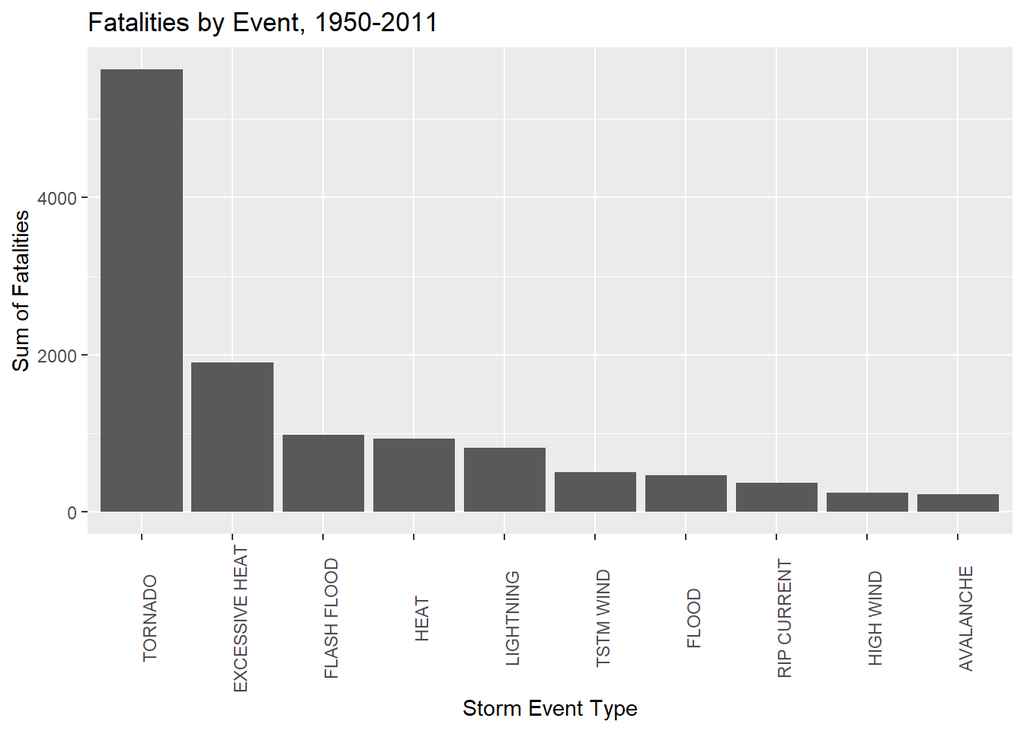

```r
#make barplot
require(ggplot2)
ggplot(fatalitySum[1:10, ], aes(x = reorder(eventType, -x), y = x)) +
        geom_bar(stat = "identity") + xlab("Storm Event Type") +
        ylab("Sum of Fatalities") + ggtitle("Fatalities by Event, 1950-2011") +
        theme(axis.text.x = element_text(angle = 90))
```

```r
#tornado > next 5
fatalitySum$x[[1]]
```

```
## [1] 5633
```

```r
sum(fatalitySum[2:6,2])
```

```
## [1] 5138
```

#### Most injurious events

The top 15 “most injurious” events are ranked below; the top 10 are shown in the bar chart. Storm events again appear to follow a Pareto distribution, this time in regard to injuries.

```r
#make tidy injuries data, then rank event by sum
injury <- stormData2[, c("id", "eventType","injuries")]
injurySum <- aggregate(injury$injuries, by = list(eventType = injury$eventType),
                       sum)
injurySum <- injurySum[order(injurySum$x, decreasing = TRUE), ]
head(injurySum, 15)
```

```
##             eventType     x
## 834           TORNADO 91346
## 856         TSTM WIND  6957
## 170             FLOOD  6789
## 130    EXCESSIVE HEAT  6525
## 464         LIGHTNING  5230
## 275              HEAT  2100
## 427         ICE STORM  1975
## 153       FLASH FLOOD  1777
## 760 THUNDERSTORM WIND  1488
## 244              HAIL  1361
## 972      WINTER STORM  1321
## 411 HURRICANE/TYPHOON  1275
## 359         HIGH WIND  1137
## 310        HEAVY SNOW  1021
## 957          WILDFIRE   911
```

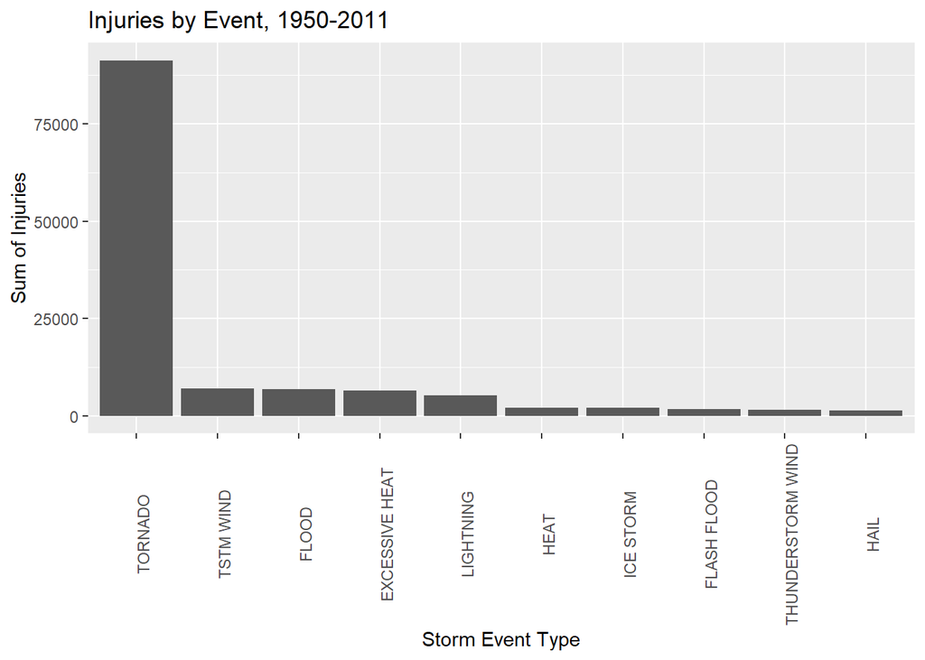

```r
#make barplot
ggplot(injurySum[1:10, ], aes(x = reorder(eventType, -x), y = x)) +
        geom_bar(stat = "identity") + xlab("Storm Event Type") +
        ylab("Sum of Injuries") + ggtitle("Injuries by Event, 1950-2011") +
        theme(axis.text.x = element_text(angle = 90))
```

```r
#tornado > all else
injurySum$x[[1]]
```

```
## [1] 91346
```

```r
sum(injurySum$x) - injurySum$x[[1]]
```

```
## [1] 49182
```

Tornados (91346 injuries) have caused the most injuries, more than all other events combined (49182 injuries).

### Economic Damage

To begin exploring the general equation “Across the United States, which types of events have the greatest economic consequences?”, I decided to answer the specific questions:

- Which types of events caused the highest costs in crop damage?
- Which types of events caused the highest costs in property damage?
- Which types of events caused the highest combined costs of economic damage?

#### Most economic damage to crops

The top 15 events causing crop damage are ranked below. Storm events again appear to follow a Pareto distribution, now with economic loss and crop damage.

```r
#make tidy crop damage data, then rank events by sum
crop <- stormData2[, c("id", "eventType","cropDamage")]
cropSum <- aggregate(crop$cropDamage, by = list(eventType = crop$eventType),
                       sum)
cropSum <- cropSum[order(cropSum$x, decreasing = TRUE), ]
head(cropSum, 15)
```

```
##             eventType           x
## 95            DROUGHT 13972566000
## 170             FLOOD  5661968450
## 590       RIVER FLOOD  5029459000
## 427         ICE STORM  5022113500
## 244              HAIL  3025954473
## 402         HURRICANE  2741910000
## 411 HURRICANE/TYPHOON  2607872800
## 153       FLASH FLOOD  1421317100
## 140      EXTREME COLD  1292973000
## 212      FROST/FREEZE  1094086000
## 290        HEAVY RAIN   733399800
## 848    TROPICAL STORM   678346000
## 359         HIGH WIND   638571300
## 856         TSTM WIND   554007350
## 130    EXCESSIVE HEAT   492402000
```

```r
#drought > next 2
cropSum$x[[1]]
```

```
## [1] 13972566000
```

```r
sum(cropSum[2:3,2])
```

```
## [1] 10691427450
```

Drought (13972566000 dollars) have caused the most crop damage, more than the next two events (flood & river flood) combined ($10691427450).

#### Most economic damage to property

The top 15 events causing property damage are ranked below. Yet another instance of a Pareto distribution, now with economic loss and property damage.

```r
#make tidy property damage data, then rank events by sum
property <- stormData2[, c("id", "eventType","propertyDamage")]
propertySum <- aggregate(property$propertyDamage,
                         by = list(eventType = property$eventType), sum)
propertySum <- propertySum[order(propertySum$x, decreasing = TRUE), ]
head(propertySum, 15)
```

```
##             eventType            x
## 170             FLOOD 144657709807
## 411 HURRICANE/TYPHOON  69305840000
## 834           TORNADO  56947380677
## 670       STORM SURGE  43323536000
## 153       FLASH FLOOD  16822673979
## 244              HAIL  15735267513
## 402         HURRICANE  11868319010
## 848    TROPICAL STORM   7703890550
## 972      WINTER STORM   6688497251
## 359         HIGH WIND   5270046295
## 590       RIVER FLOOD   5118945500
## 957          WILDFIRE   4765114000
## 671  STORM SURGE/TIDE   4641188000
## 856         TSTM WIND   4484928495
## 427         ICE STORM   3944927860
```

```r
#flood > next 2
propertySum$x[[1]]
```

```
## [1] 144657709807
```

```r
sum(propertySum[2:3,2])
```

```
## [1] 126253220677
```

#### Most economic damage to crops and property combined

The top 15 events causing combined economic damage are ranked below; the bar plot shows the top 10 events. Yet another instance of a Pareto distribution, now with combined economic loss.

```r
#add prop & crop damage, then rank events by sum
econ <- stormData2[, c("id", "eventType","cropDamage", "propertyDamage")]
econ$econDamage <- with(econ, econ$cropDamage + econ$propertyDamage)
econSum <- aggregate(econ$econDamage, by = list(eventType = econ$eventType),
                       sum)
econSum <- econSum[order(econSum$x, decreasing = TRUE), ]
head(econSum, 15)
```

```
##             eventType            x
## 170             FLOOD 150319678257
## 411 HURRICANE/TYPHOON  71913712800
## 834           TORNADO  57362333947
## 670       STORM SURGE  43323541000
## 244              HAIL  18761221986
## 153       FLASH FLOOD  18243991079
## 95            DROUGHT  15018672000
## 402         HURRICANE  14610229010
## 590       RIVER FLOOD  10148404500
## 427         ICE STORM   8967041360
## 848    TROPICAL STORM   8382236550
## 972      WINTER STORM   6715441251
## 359         HIGH WIND   5908617595
## 957          WILDFIRE   5060586800
## 856         TSTM WIND   5038935845
```

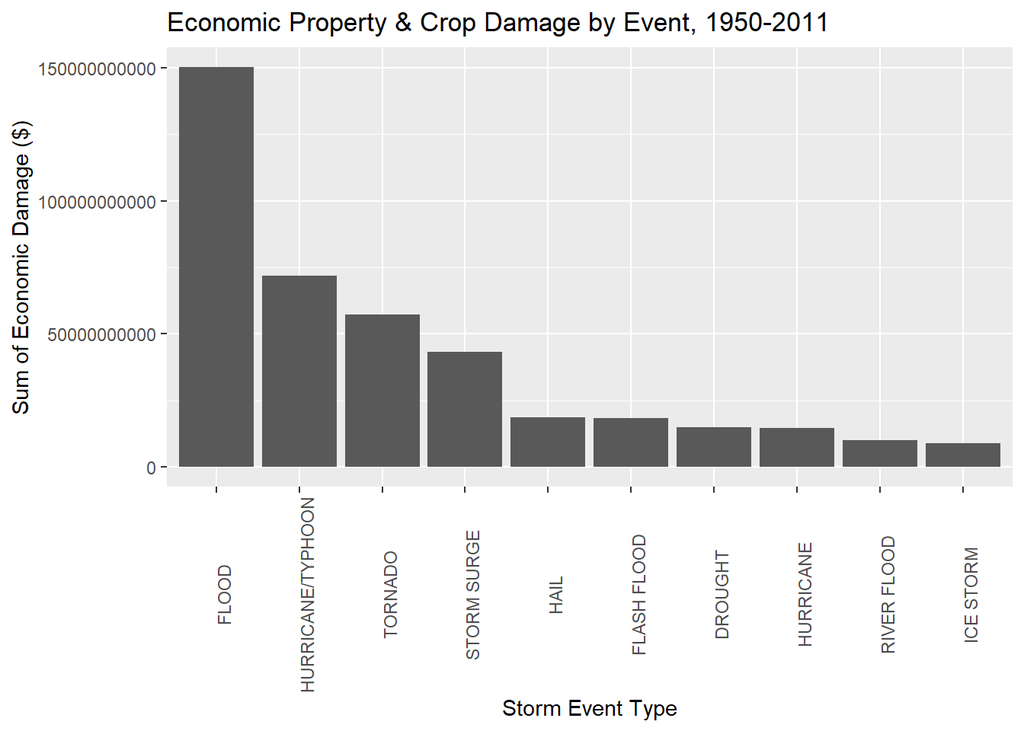

```r
#make barplot
require(ggplot2)
ggplot(econSum[1:10, ], aes(x = reorder(eventType, -x), y = x)) +
        geom_bar(stat = "identity") + xlab("Storm Event Type") +
        ylab("Sum of Economic Damage ($)") +
        ggtitle("Economic Property & Crop Damage by Event, 1950-2011") +
        theme(axis.text.x = element_text(angle = 90))
```

```r
#drought > next 2
econSum$x[[1]]
```

```
## [1] 150319678257
```

```r
sum(econSum[2:3,2])
```

```
## [1] 129276046747
```

Floods (150319678257 dollars) have caused the most economic damage, more than the next two events (hurricane & tornado) combined ($129276046746.5).